# KNN ile Zaman Serisi Tahmini: tsfknn Paketi

# 1 KNN(k Nearest Neighbours)

$~$$~$ Hem sınıflandırma hem de regresyon problemlerinin çözümünde kullanılıyor olmakla birlikte, endüstride çoğunlukla sınıflandırma problemlerinin çözümünde kullanılmaktadır. KNN algoritmaları, 1967 yılında T. M. Cover ve P. E. Hart tarafından önerilmiştir. Algoritma, sınıfları belli olan bir örnek kümesindeki verilerden yararlanılarak kullanılmaktadır. Örnek veri setine katılacak olan yeni verinin, mevcut verilere göre uzaklığı hesaplanıp, k sayıda yakın komşuluğuna bakılır.

Uzaklık hesapları için genelde 3 tip uzaklık fonksiyonu kullanılmaktadır:

- Oklid uzaklığı
- Minkowski uzaklığı
- Manhattan uzaklığı

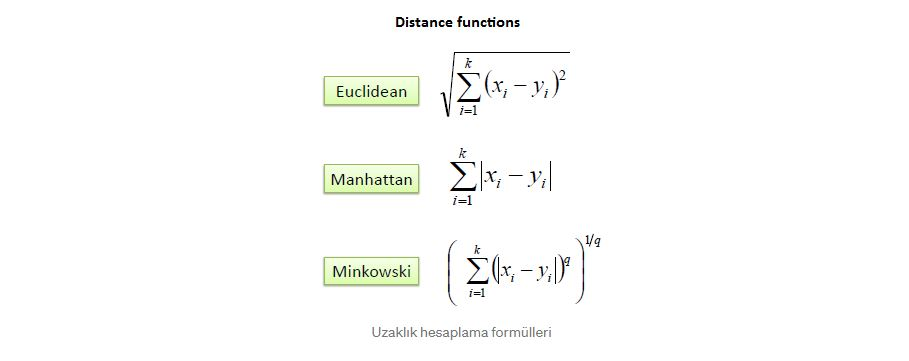

$~$$~$ Hepsi tek bir ana fonksiyondan türetilmektedir. Minkowski fonksiyonundaki q=1 değeri için manhattan uzaklığı; q=2 değeri için öklid uzaklık formulünü elde ediyoruz. Bu sebeple minkowski genel formulunu kullanarak uygulamamızı yapacağız. Böylece diğer uzaklık ölçümleri için sadece q değerini değiştirmemiz yeterlidir. Öklid uzaklığı, 2 boyutlu uzayı ele aldığımızda,aslında pisagor teoreminin uygulanmasıdır. Q sayıda değişkene bağlı bir uzaklık hesaplamak isteniyorsa Minkowski yöntemi kullanılır. Formülde Q yerine 2 değerini verirsek aslında Öklid bağlantısını elde ettiğimizi görebiliriz.

$~$$~$ K-NN ( K-Nearest Neighbor) algoritması en çok kullanılan sınıflandırma algoritmasından biridir. K-NN non-parametric (parametrik olmayan), lazy (tembel) bir öğrenme algoritmasıdır. lazy kavramını anlamaya çalışırsak eager(istekli) learning aksine lazy learning’in bir eğitim aşaması yoktur. Eğitim verilerini öğrenmez, bunun yerine eğitim veri kümesini “ezberler”. Bir tahmin yapmak istediğimizde, tüm veri setinde en yakın komşuları arar.

Adımlar

KNN_Algoritmasının_Adımları

1. Adım

Sınıf nitelikleri belli olan elemanlardan oluşan bir uzaya yeni bir örnek ekle.

2. Adım

K sayısını belirle.

3. Adım

Yeni gelen örnek ile elemanlar arasındaki uzaklığı hesapla.(Uzaklık fonksiyonlardan birini kullanarak)

4. Adım

En yakın olan k tane elemanın sınıf niteliğine bak.

5. Adım

En yakın olan k tane elemanlardan sınıf değeri sayıca fazla olan sınıfa örneği dahil et.

$~$$~$ KNN en basit anlamı ile içerisinde tahmin edilecek değerin bağımsız değişkenlerinin oluşturduğu vektörün en yakın komşularının hangi sınıfta yoğun olduğu bilgisi üzerinden sınıfını tahmin etmeye dayanır.

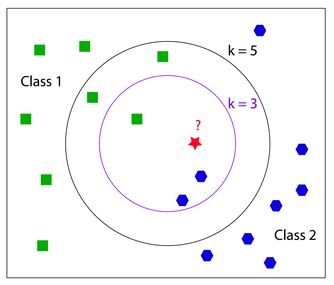

$~$$~$ Makine öğrenmesi ile çözülebilen problemlerden biri çok geniş kullanım alanı ile sınıflandırma problemleridir. Günümüzdeki bir çok problem bir şekilde sınıflandırma problemi olarak tasarlanıp çözülebilmektdir.

- KNN algoritması küçük bir örnek:

| Boy_Verisi | Kilo_Verisi | Cinsiyet |
| --- | --- | --- |
| 180 | 80 | Erkek |
| 170 | 70 | Erkek |
| 150 | 65 | Kadın |
| 160 | 55 | Kadın |
| 175 | 65 | Kadın |
| 185 | 90 | Erkek |
| 173 | 100 | Erkek |
| 183 | 110 | Erkek |
| 153 | 60 | Kadın |
| 163 | 45 | Kadın |

```r
KNN_Cinsiyet<-function(dataSet,boy,kilo,k){
  euclid <- c()
  for (i in 1:nrow(dataSet)){
    euclid <- append(euclid,sqrt(sum((dataSet[i,1:2]-c(boy,kilo)) ^ 2)))
  }
  enYakinKData <- as.data.frame(euclid)
  enYakinKData <- data.frame(Satir_No=row(enYakinKData),Oklid_Mesafeleri=euclid)
  enYakinKDataOrder <- enYakinKData[order(enYakinKData$Oklid_Mesafeleri),]
  enYakinKDataOrder2 <- cbind(enYakinKDataOrder,Cinsiyet=data[enYakinKDataOrder$Satir_No,3])
  countx<-count(enYakinKDataOrder2[1:k,],Cinsiyet)
  if (nrow(countx) == 1){
    sonuc <- countx[1,]$Cinsiyet
  } else if (countx[1,]$n > countx[2,]$n) {
    sonuc <- countx[1,]$Cinsiyet
  } else if(countx[1,]$n == countx[2,]$n){
    sonuc <- "En yakın komşu sayısı eşit çıkmıştır."
  } else {
    sonuc <- countx[2,]$Cinsiyet
  }
  return(sonuc)
}
```

```r
KNN_Cinsiyet(data,160,70,3)
```

```
[1] "Kadın"
```

**KNN ne zaman kullanlır ?**

$~$$~$ Algoritma, veri araştırmacısının benzer belgeler için semantik olarak aradığı konsept araştırmasında kullanılır. Keşfetmek, algoritmanın verilen soruyla ilgili tüm e-postaları, kısa özetleri, sözleşmeleri, vb. bulmak için kullanılabileceği başka bir kullanım senaryosudur. Tavsiye sistemlerinde genellikle bir müşterinin belirli bir öğeyi beğendiğini biliyorsanız, KNN’yi entegre eder, daha sonra bunlara benzer öğeler önerebilirsiniz. Son olarak, k-NN, Yapay Sinir Ağları (ANN) ve Destek Vektör Makineleri (SVM) gibi daha karmaşık sınıflandırıcılar için bir ölçüt olarak sıklıkla kullanılır.

$~$$~$ Aşağıdaki problemler sınıflandırma problemlerine örnek olarak verilebilir:

- Müşterinin verilen krediyi ödeyip ödeyemeyeceği (Customer Default Risk)
- Müşterinin aldığı servisi bırakıp bırakmayacağı (Customer Churn)
- Müşteri segmantasyon (Customer Segmantation)
- Kişiye özel ilaç tespiti
- E-posta spam filitrelemesi
- Görüntü tanıma (Image Recognition)
- El yazısı tanıma (Handwriting Recognition)
- Biyometrik tanımlama (Biometric Identification)

# 2 Zaman Serisi Nedir?

$~$$~$ Bir zaman serisi, ilgilenilen bir büyüklüğün zaman içerisinde sıralanmış ölçümlerinin bir kümesidir. Zaman serisi ile ilgili bu analizin yapılma amacı ise, gözlem kümesince temsil edilen gerçeğin anlaşılması ve zaman serisindeki değişkenlerin gelecekteki değerlerinin doğru bir şekilde tahmin (forecast) edilmesidir .

- Zaman serisi analizi; zaman içerisinde gelişen olayların ve işlemlerin analiz edilmesi ve iç görüye dönüştürülmesi ile tarihsel etkileri anlamak için önemli bir tekniktir.
- Zaman etkisiyle değişen olaylardan elde edilecek çıkarımlar ve bu etkilenmelerin işaretlenmesi, nedensellik ve anlam ilişkisi kurmak için oldukça faydalıdır.
- Zaman serileri; zamana göre (kronolojik) sıralanan veri dizileridir, veri satırları periyodik (saat, gün, ay, yıl vb.) bir döngü ile sıralanırlar.
- Zaman serileri sayısal olarak ifade edilebilecek olayların ve işlemlerin bir zaman damgası ile ilişkilendirildiği basit veri setleri olarak da tanımlanabilir.
- Zaman boyutları (Time) ardışık bir halde gözlemler (Observation) ile yan yana geldiklerinde zaman dizilerini oluşturmaktadır.
- Zaman serilerinin bir tarih aralığına (sınırlılık) sahip olması, onların tarih üzerinde bir örneklem olduğunu varsaymamızı gerektirir.

*“Bir zaman serisi, zaman içinden alınan ardışık bir dizi gözlemdir.”*

Örneğin;

$~$$~$ Bir insanın gün içerisinde attığı adım sayısı bir zaman serisi örneğidir, günler ile işaretlenecek olan adım sayıları, günler ile birlikte bir zaman serisi oluşturmaktadır.

Bu örnekte gün serinin zaman boyutudur, adım sayısı ise gözlemdir.

Bir insanın gün içerisinde attığı adım sayısı

| Günler_Zaman | Adım_Sayısı_Gözlem |
| --- | --- |
| 21-01-2020 | 2236 |
| 22-01-2020 | 1652 |
| 23-01-2020 | 1725 |
| 24-01-2020 | 2699 |
| 25-01-2020 | 2756 |

- Bir başka örnek;

$~$$~$ Bir işletmenin aylık satış verilerinin zaman damgası ile işaretli olduğu ve zaman üzerinde sıralanmış olduğu bir veri seti; zaman serisi verisidir, bu veri setinde zaman boyutu aylar, gözlemler ise satışlarla temsil edilmiş olur.

Bir işletmenin aylık satış verileri

| Ay_Zaman | Satışlar_Gözlem |
| --- | --- |
| Ocak | 210.010 TL |
| Şubat | 230.883 TL |
| Mart | 210.603 TL |
| Nisan | 260.218 TL |
| Mayıs | 280.368 TL |

- Zaman serileri dört bileşenden oluşur;
1. Trend(Genel Eğilim) bileşeni; Zaman serilerinin uzun sürede gösterdiği düşme ve yükselme süreçlerinden sonra oluşan kararlı durumdur. Zaman serileri uzun dönem açısından kararlı alçalma ya da yükselme şeklinde bir eğilime sahiptir.
2. Mevsim Bileşeni; Zaman serilerinde mevsimlere göre değişmeyi ifade eder.Zaman serileri açısından kullanılan verilerin kimi dönemleri diğer dönemlere göre farklılık gösterir.
3. Çevrimsel Bileşen(Konjonktürel); Ekonomide, mevsimsel değişmeler ile ilgili olmayan dönemsel değişmelerdir.Örneğin,ekonomide genel eğilimden bağımsız kısa süreli genişleme ya da daralma durumu çevrimsel süreci tarif eder.
4. Düzensiz Bileşen(Rassal); Diğer unsurlar gibi belirli olmayan, hata terimi ile ifade edilebilecek değişmelerdir.

$~$$~$ Zaman serileri analizlerinde kullanılan bazı grafikler:

**time series plot**

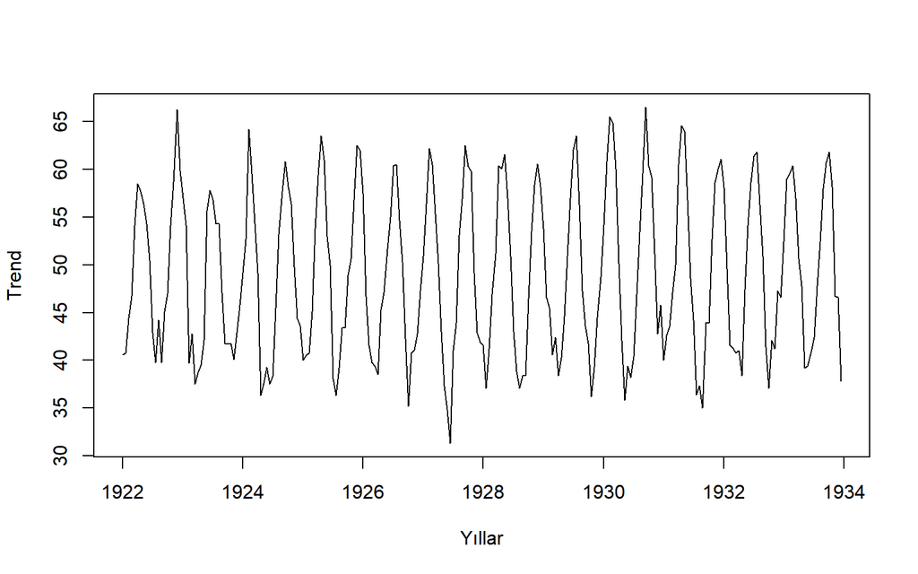

**Mevsimsel Çizelge (Seasonal Plot)**

$~$$~$ Seasonal plot; farklı yıllardaki zaman serilerini üst üste görselleştirerek, her bir yılın sezonsal farklılığını ve ortak yanlarını anlamamıza yardımcı olan veri görselleştirme aracıdır.

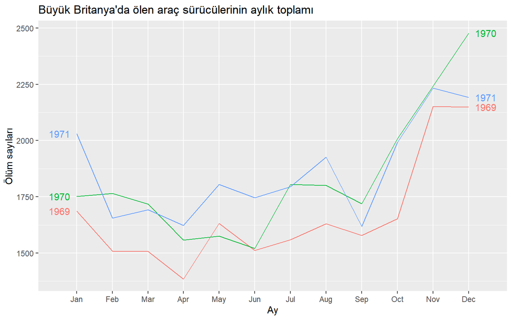

$~$$~$ Seasonal plot üzerinde mevsimsel farklılıkları polarizasyon ile incelemek istersek, farklı bir yöntem olan polar (kutupsal) görselleştirme varyasyonunu da kullanabiliriz. Kodlar üzerinde yapacağımız polar = TRUE düzenlemesi, zaman serisinin eksenini aşağıda gösterildiği gibi yatay yerine dairesel yapar.

**Polar Seasonal Plot**

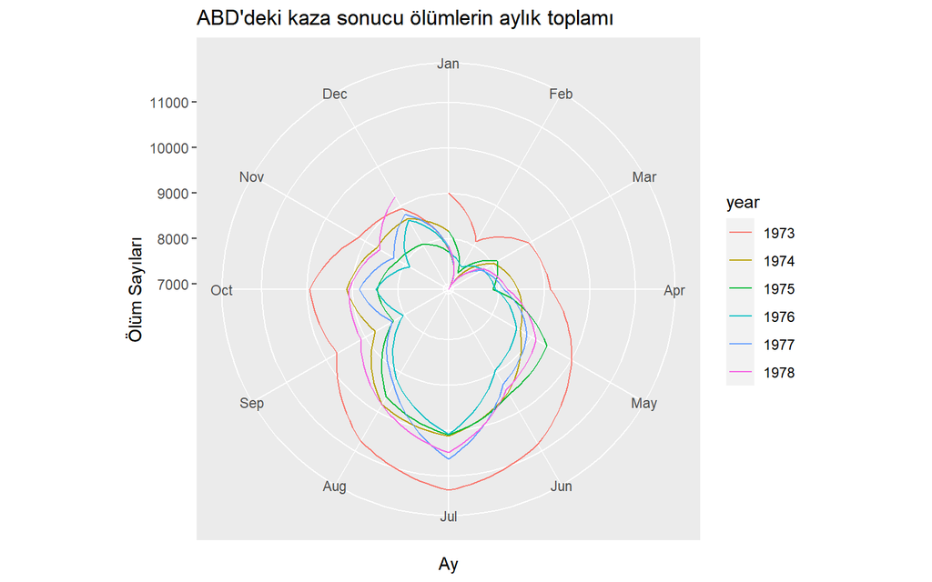

# 3 R programında KNN ile Zaman Serisi Tahmini: tsfknn Paketi

$~$$~$ KNN, sınıflandırma ve regresyonda kullanılan çok popüler bir algoritmadır. Bu algoritma, bir örnek koleksiyonunu saklar. Regresyonda, her örnek, örneği açıklayan bir özellik vektöründen ve onun ilişkili sayısal hedef değerinden oluşur. Yeni bir örnek verildiğinde, KNN, Öklid mesafesi gibi bir uzaklık ölçüsüne göre en yakın komşular olarak adlandırılan k en benzer örneğini bulur ve değerini en yakın komşularıyla ilişkili hedef değerlerin bir toplamı olarak tahmin eder.

$~$$~$ i. eğitim örneği, n özellikli bir vektör : $f^{i}_{1},f^{i}_{2},f^{i}_{3},...,f^{i}_{n}$, ve örneği açıklayan ve onunla ilişkili m öznitelikli hedef vektörü $t^{i}_{1},t^{i}_{2},t^{i}_{3},...,t^{i}_{n}$. vektöründen oluşur. Özellikleri bilinen ancak hedefi bilinmeyen yeni bir örnek verildiğinde, yeni örneğin özellikleri, özelliklerin vektörlerine ve bir benzerlik veya uzaklık ölçüsüne göre “k” en benzer eğitim örneklerini bulmak için kullanılır. Örneğin, benzerlik metriğinin Öklid mesafesi olduğunu varsayarsak, yeni örnek ile i. eğitim örneği arasındaki mesafe aşağıdaki gibi hesaplanır:

$$Öklid=\sqrt{\sum_{x=1}^n (e_x^i-q_x)^2}$$

$~$$~$ Yeni verilen örneğe en yakın olan “k” eğitim örnekleri, k en yakın komşuları olarak kabul edilir. Yeni bir örnek verildiğinde, en yakın komşularının hedeflerinin muhtemelen bilinmeyen hedefle benzer olduğu düşünülmektedir. Bu şekilde, en yakın komşuların hedefleri, yeni örneğin hedefini tahmin etmek için toplanır. Örneğin, hedefler veya k en yakın komşu vektörü olduğunu varsayarsak: " yeni örneğin hedefini şu şekilde tahmin etmek için ortalamaları alınabilir:

$$\sum_{i=1}^k \frac{t^i}{k}$$

$~$$~$ Kısacası, KNN n özellik tarafından tanımlanan eğitim örneklerinin bir koleksiyonunu depolar. Her eğitim örneği, n boyutlu bir uzaydaki bir noktayı temsil eder. Yeni bir örnek verildiğinde, KNN, mevcut hedeflerinin bilinmeyen hedefe benzer olması umuduyla n boyutlu uzayda k en yakın örneklerini bulur. Bir eğitim örneğiyle ilişkili hedef değeri, zaman serilerinin değerlerinin bir koleksiyonudur ve örneği açıklayan özellikler, hedefin gecikmeli değerleridir. Bir eğitim örneğinin hedefi zaman serisinin bir değeri olduğundan yalnızca bir değer tahmin edilecektir.

$~$$~$ Ayrıca, bir hedefi tanımlayan özelliklerin, onun zaman serisindeki ilk on iki gecikmeli değeri olduğuna karar verdiğimizi varsayalım. t zaman serisi ile ilişkili eğitim örnekleri veya örnekler Tablo 1’de gösterilmektedir. Özellik vektörü olarak 1’den 12’ye kadar gecikmeleri kullandığımız için, bir sonraki gelecek noktayla ilişkili özellik vektörü, zaman serisinin son on iki değerinden oluşan vektördür (x121, x122, …, x132).

$~$$~$ Örneğin, k 2’ye eşitse, yeni örneğin en yakın 2 komşuları bulunur ve hedefleri gelecek ayı tahmin etmek için toplanır. Zaman serisi tahmini için KNN kullanımının arkasındaki mantık, bir zaman serisinin tekrarlayan modeller içerebilmesidir. Bir zaman serisinin son modeli göz önüne alındığında, sonraki modellerinin zaman serisinin gelecekteki değerlerine benzer olacağı ümidiyle geçmişte benzer kalıplar ararız.

$~$$~$ Knn_examples ile eğitim örneklerine başvurmadan önce, modeli oluşturmak gerekir. Bu, bir zaman serisiyle ilişkili bir model oluşturan ve modeli zaman serisinin gelecekteki değerlerini tahmin etmek için kullanan knn_forecasting fonksiyonu ile yapılır. knn_forecasting çok kullanışlıdır çünkü yukarıda açıklandığı gibi KNN modelini oluşturur ve daha sonra modeli zaman serilerini tahmin etmek için kullanır. Bu fonksiyon, model bilgisi ve tahmini ile bir “knnForecast” nesnesi döndürür. Yukarıda gördüğümüz gibi, modelle ilgili eğitim örneklerini görmek için knn_examples fonksiyonunu kullanabilirsiniz. Ayrıca, tahmine başvurabilir veya “knnForecast” nesnesi aracılığıyla bunun grafiğini plot fonksiyonu ile çizdirebiliriz.

- Örneklere başlamadan önce paket içerisinde yer alan fonksiyonları ve argümanlarını incelersek:

## 3.1 Tsfknn paketindeki fonksiyonlar ve yöntemler

[output not shown]

| Features | Target |
| --- | --- |
| $X_{1}$,$X_{2}$,$X_{3}$,$X_{4}$,$X_{5}$,$X_{6}$,$X_{7}$,$X_{8}$,$X_{9}$,$X_{10}$,$X_{11}$,$X_{12}$ | $X_{13}$ |
| $X_{2}$,$X_{3}$,$X_{4}$,$X_{5}$,$X_{6}$,$X_{7}$,$X_{8}$,$X_{9}$,$X_{10}$,$X_{11}$,$X_{12}$,$X_{13}$ | $X_{14}$ |
| $X_{3}$,$X_{4}$,$X_{5}$,$X_{6}$,$X_{7}$,$X_{8}$,$X_{9}$,$X_{10}$,$X_{11}$,$X_{12}$,$X_{13}$,$X_{14}$ | $X_{15}$ |
| … | … |
| $X_{120}$,$X_{121}$,$X_{122}$,$X_{123}$,$X_{124}$,$X_{125}$,$X_{126}$,$X_{127}$,$X_{128}$,$X_{129}$,$X_{130}$,$X_{131}$ | $X_{132}$ |

Tablo 1: t zaman serisi ile ilişkili eğitim örnekleri

**tsfknn paketinin bir zaman serisini tahmin etmek için nasıl kullanılmaktadır ?**

```
      Jan  Feb  Mar  Apr  May  Jun  Jul  Aug  Sep  Oct  Nov  Dec
1920 40.6 40.8 44.4 46.7 54.1 58.5 57.7 56.4 54.3 50.5 42.9 39.8
1921 44.2 39.8 45.1 47.0 54.1 58.7 66.3 59.9 57.0 54.2 39.7 42.8
1922 37.5 38.7 39.5 42.1 55.7 57.8 56.8 54.3 54.3 47.1 41.8 41.7
1923 41.8 40.1 42.9 45.8 49.2 52.7 64.2 59.6 54.4 49.2 36.3 37.6
1924 39.3 37.5 38.3 45.5 53.2 57.7 60.8 58.2 56.4 49.8 44.4 43.6
1925 40.0 40.5 40.8 45.1 53.8 59.4 63.5 61.0 53.0 50.0 38.1 36.3
 [ reached getOption("max.print") -- omitted 14 rows ]
```

$~$$~$ **nottem** veri seti, Nottingham Kalesi’nde 20 yıl boyunca Fahrenheit derece cinsinden ortalama hava sıcaklıklarını içeren bir zaman serisi nesnesidir.

```
[1] "ts"
```

$~$$~$ Bu veri setinin classına baktığımızda “ts” olduğunu görüyoruz. “ts” fonksiyonu, zaman serisi nesneleri oluşturmak için kullanılmaktadır.

$~$$~$ Örneğimizi daha iyi açıklayabilmek için veri setinde ilk 3 yılı ele alıp 1923 yılının ilk ayını tahmin etmeye çalışacağız. Bu yüzden **window** fonksiyonu ile veri setimizde kaç yılına kadar almak istiyorsak argüman olarak belirtip **timeS** değişkinene atama işlemini gerçekleştirdik. Ardından **knn_forecasting** fonksiyonu ile zaman serilerini tahmin etmek için bir KNN modeli oluşturduk ve bu zaman serilerinin gelecekteki değerlerine ilişkin bir tahmin yapmak için kullanmış olduk. Bu fonksiyon ile model ve tahmin hakkındaki bilgiler bir “knnForecast” nesnesinde döndürülür ve bu nesneyi **pred** adında oluşturduğmuz değişkene atama işlemini gerçekleştirdik. **knn_forecasting** fonksiyonuna veri setimizi, tahmin sayımızı(**h=1**), en yakın komşu olarak bakmasını istediğimiz sayıyı(**k=2**) ve gecikmeleri yani özelliklerimizi yılın ayları şeklinde tahminleyeceğimiz için 1:12 olarak yazdık. **knn_examples** fonksiyonuna pred değişkenini argüman olarak vererek bir KNN modeliyle ilişkili örnekleri görebilmiş olduk.

```
      Jan  Feb  Mar  Apr  May  Jun  Jul  Aug  Sep  Oct  Nov  Dec
1920 40.6 40.8 44.4 46.7 54.1 58.5 57.7 56.4 54.3 50.5 42.9 39.8
1921 44.2 39.8 45.1 47.0 54.1 58.7 66.3 59.9 57.0 54.2 39.7 42.8
1922 37.5 38.7 39.5 42.1 55.7 57.8 56.8 54.3 54.3 47.1 41.8 41.7
```

```
      Lag12 Lag11 Lag10 Lag9 Lag8 Lag7 Lag6 Lag5 Lag4 Lag3 Lag2 Lag1   H1
 [1,]  40.6  40.8  44.4 46.7 54.1 58.5 57.7 56.4 54.3 50.5 42.9 39.8 44.2
 [2,]  40.8  44.4  46.7 54.1 58.5 57.7 56.4 54.3 50.5 42.9 39.8 44.2 39.8
 [3,]  44.4  46.7  54.1 58.5 57.7 56.4 54.3 50.5 42.9 39.8 44.2 39.8 45.1
 [4,]  46.7  54.1  58.5 57.7 56.4 54.3 50.5 42.9 39.8 44.2 39.8 45.1 47.0
 [5,]  54.1  58.5  57.7 56.4 54.3 50.5 42.9 39.8 44.2 39.8 45.1 47.0 54.1
 [ reached getOption("max.print") -- omitted 19 rows ]
```

$~$$~$ Knn_examples ile eğitim örneklerine başvurmadan önce, modeli oluşturmamız gerektiğinden bahsetmiştik. Bu, bir zaman serisiyle ilişkili bir model oluşturan ve modeli zaman serisinin gelecekteki değerlerini tahmin etmek için kullanan knn_forecasting fonksiyonu ile yapabilmekteyiz.

**Peki nasıl çalışır ?**

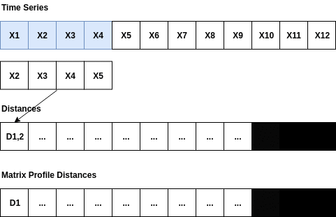

```
      Lag12 Lag11 Lag10 Lag9 Lag8 Lag7 Lag6 Lag5 Lag4 Lag3 Lag2 Lag1   H1
 [1,]  40.6  40.8  44.4 46.7 54.1 58.5 57.7 56.4 54.3 50.5 42.9 39.8 44.2
 [2,]  40.8  44.4  46.7 54.1 58.5 57.7 56.4 54.3 50.5 42.9 39.8 44.2 39.8
 [3,]  44.4  46.7  54.1 58.5 57.7 56.4 54.3 50.5 42.9 39.8 44.2 39.8 45.1
 [4,]  46.7  54.1  58.5 57.7 56.4 54.3 50.5 42.9 39.8 44.2 39.8 45.1 47.0
 [5,]  54.1  58.5  57.7 56.4 54.3 50.5 42.9 39.8 44.2 39.8 45.1 47.0 54.1
 [ reached getOption("max.print") -- omitted 19 rows ]
```

$~$$~$ Zaman serisi veri setindeki ilk yılın 12 ayını özellik vektörü olarak ilk hedef değerini ise 2. yılın ilk ayı olarak ele alır. 2. özellik vektörümüz ise ilk özellik vektöründeki ilk yılın ilk ayından hemen sonraki 12 ayı özellik vektörü olarak ve hedef değerini ise 3. yılın ilk ayı olarak ele alarak devam eder. Son hedef değerimiz ise veri setimizin son ayı ve özellik vektörümüz ise son ayımızından hemen önceki ilk 12 aydır.

$~$$~$ Özellik olarak gecikmeleri 1: 12’yi kullandığımız için, zaman serisinin bir sonraki gelecek değerin (1923 yılının Ocak ayı) özellik vektörü, zaman serisinin son on iki değeridir.

$~$$~$ Tahminin nasıl yapıldığını görebiliriz. Yani, hedefi tahmin edilen yeni örneğe ve en yakın komşularına bakabiliriz. Bu bilgi, bir “knnForecast” nesnesine uygulanmış “nearest_neighbors” fonksiyonu ile elde edilir:

```
$instance
Lag 12 Lag 11 Lag 10  Lag 9  Lag 8  Lag 7  Lag 6  Lag 5  Lag 4  Lag 3  Lag 2
  37.5   38.7   39.5   42.1   55.7   57.8   56.8   54.3   54.3   47.1   41.8
 Lag 1
  41.7

$nneighbors
  Lag 12 Lag 11 Lag 10 Lag 9 Lag 8 Lag 7 Lag 6 Lag 5 Lag 4 Lag 3 Lag 2 Lag 1
1   40.6   40.8   44.4  46.7  54.1  58.5  57.7  56.4  54.3  50.5  42.9  39.8
2   40.8   44.4   46.7  54.1  58.5  57.7  56.4  54.3  50.5  42.9  39.8  44.2
    H1
1 44.2
2 39.8
```

- **nearest_neighbors** fonksiyonu bize tahmin etmeye çalıştığımız hedefin yeni örneği veya özellik vektörünü ve bu özellik vektörüne en yakın olan 2 komşusunun özellik ve hedef vektörünü verir.

$~$$~$ **En yakın iki komşu ise şu şekilde belirlenir:**

- **knn_examples(pred)** ile veri setimizdeki veri sayısı ile gecikme değerlerimizin farkı kadar satır elde ederiz. Yani 1923 yılına kadar verilerimizi aldık ve 1923 yılının ilk ayını tahmin etmeye çalıştığımız için bize ilk 3 yıldan 36 tane sıcaklık değeri gelir. Bu durumda 24 tane gecikme değerleri ve hedef değei olan satır elde ederiz.
- knn_examples(pred) ile elde ettiğimiz gecikmeleri ve hedefleri bir matrise dönüştürerek en yakın 2 komşuyu kendimiz bulmak istersek:

```
 [1]  1  2 13 24 14 12 23  3 15 11  4 22 10 16  5  9 21  6  7 17  8 20 18 19
```

$~$$~$ Kendimiz elde etmek istediğimizde de öklid mesafelerine bakarak en yakın 2 komşunun, knn_examples(pred) sonucundaki 1. ve 2. satır olduğunu teyit etmiş olduk.

```
     Jan
1923  42
```

$~$$~$ 1923 yılının ilk ayının tahmin değeri 42 Fahrenheit olarak bulunmuştur. Bu değer, tahmin etmeye çalıştığımız hedefin özellik vektörüne en yakın olan 2 komşusunun hedef değerlerinin ortalamasıdır.

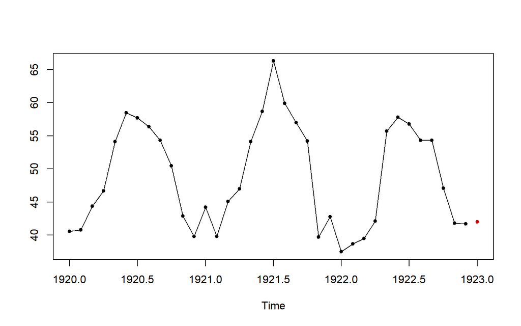

$~$$~$ **knnForecast** nesnesi aracılığıyla bunun grafiğini çizdirebileceğimizden bahsetmiştik. Grafiğimizi çizdirdiğimizde; y ekseninde Fahrenheit değerleri ve x ekseninde yıllarımız yer almaktadır. Tahmin edilen değerimiz kırmızı nokta ile grafikte belirtilmiştir.

$~$$~$ Yeni örneği, en yakın komşularını ve tahmini içeren olay örgüsü aşağıdaki grafik ile de görselleştirilebilir: (Bu grafik için “ggplot2” kütüphanesine ihtiyaç vardır.)

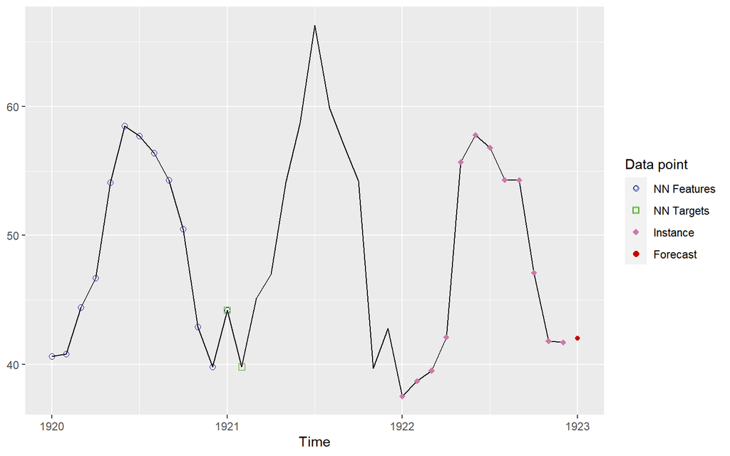

$~$$~$ Bu grafik bize 4 farklı sembol ile görsellik sağlar.

- Bu semboller:
1. Forecast: Tahmin edilen değeri gösterir.
2. Instance: Tahmin etmeye çalıştığımız hedefin özellik vektörüne ait değerleri gösterir.
3. NN Targets: En yakın k komşudaki hedef değerleri gösterir.
4. NN Features: En yakın k komşudaki özellik vektörüne ait değerleri gösterir.

## 3.2 Çok Adımlı İleriye Dönük Stratejiler

$~$$~$ Bir önceki bölümde, KNN ile bir adım ileri tahmin için örnek yapmıştık. Aynı zamanda, gelecekte birden fazla değeri tahmin etmekte çok yaygın bir kullanımdadır. Bu amaçla, çok adımlı bir ileri strateji seçilerek çoklu tahmin yapılabilir. Bu pakette iki ortak strateji vardır:

1. MIMO—Çoklu Girdi Çoklu Çıktı Stratejisi
2. Özyinelemeli Strateji
- Yalnızca bir gelecek değeri tahmin edildiğinde her iki stratejide aynı çalışma mantığını göstermektedir.

### 3.2.1 MIMO Stratejisi - Multiple-Input and Multiple-Output

$~$$~$ Çoklu Girdi Çoklu Çıktı stratejisi yaygın olarak KNN ile uygulanır ve hedef değerlerin bir vektörünün kullanılması ile karakterize edilir. Bu vektörün uzunluğu tahmin edilecek periyotların sayısına eşittir. Örneğin, Büyük Britanya’da aylık ölen toplam otomobil sürücülerini veren bir zaman serisiyle çalıştığımızı varsayalım ve önümüzdeki 12 ay için ölenlerin sayısını tahmin etmek istiyoruz. Bu durumda, özellik olarak kullanılan gecikmeler için iyi bir seçim 1:12 olacaktır.

$~$$~$ Eğer MIMO stratejisi seçilirse, bir eğitim örneği şunlardan oluşur:

• 12 ay ardışık ölüm sayılarına sahip bir hedef vektör ve

• Ardışık önceki 12 aydaki ölümlerin sayısını gösteren bir özellik vektörü–hedef vektörün 12 ayından hemen önce.

$~$$~$ Yeni örnek(instance), zaman serisinin son 12 ayında ölen araba sürücülerinin sayısı olacaktır. Bu şekilde, zaman serilerinde son 12 aya en çok benzeyen ölüm sayısını ararız ve sonraki 12 ayı tahmin ederiz.

- Aşağıdaki örnekte, MIMO stratejisini kullanarak önümüzdeki 12 ayı tahmin etmeye çalışacağız:

```
      Jan  Feb  Mar  Apr  May  Jun  Jul  Aug  Sep  Oct  Nov  Dec
1969 1687 1508 1507 1385 1632 1511 1559 1630 1579 1653 2152 2148
1970 1752 1765 1717 1558 1575 1520 1805 1800 1719 2008 2242 2478
1971 2030 1655 1693 1623 1805 1746 1795 1926 1619 1992 2233 2192
1972 2080 1768 1835 1569 1976 1853 1965 1689 1778 1976 2397 2654
1973 2097 1963 1677 1941 2003 1813 2012 1912 2084 2080 2118 2150
1974 1608 1503 1548 1382 1731 1798 1779 1887 2004 2077 2092 2051
 [ reached getOption("max.print") -- omitted 10 rows ]
```

$~$$~$ **UKDriverDeaths** veri seti; Ocak 1969 ile Aralık 1984 arasında Büyük Britanya’da ölen veya ciddi şekilde yaralanan araç sürücülerinin aylık toplamını veren bir zaman serisidir.

$~$$~$ Örneğimizi daha iyi açıklayabilmek için veri setinde ilk 3 yılı ele alıp 1972 yılındaki ölen veya ciddi şekilde yaralanan araç sürücülerinin aylık toplamını tahmin etmeye çalışacağız.

$~$$~$ knn_forecasting fonksiyonun **msas** argümanına **“MIMO”** yazarak çoklu girdi çoklu çıktı stratejisini uygulayabiliriz.

```
      Lag12 Lag11 Lag10 Lag9 Lag8 Lag7 Lag6 Lag5 Lag4 Lag3 Lag2 Lag1   H1   H2
 [1,]  1687  1508  1507 1385 1632 1511 1559 1630 1579 1653 2152 2148 1752 1765
 [2,]  1508  1507  1385 1632 1511 1559 1630 1579 1653 2152 2148 1752 1765 1717
 [3,]  1507  1385  1632 1511 1559 1630 1579 1653 2152 2148 1752 1765 1717 1558
        H3   H4   H5   H6   H7   H8   H9  H10  H11  H12
 [1,] 1717 1558 1575 1520 1805 1800 1719 2008 2242 2478
 [2,] 1558 1575 1520 1805 1800 1719 2008 2242 2478 2030
 [3,] 1575 1520 1805 1800 1719 2008 2242 2478 2030 1655
 [ reached getOption("max.print") -- omitted 10 rows ]
```

```
      Jan  Feb  Mar  Apr  May  Jun  Jul  Aug  Sep  Oct  Nov  Dec
1969 1687 1508 1507 1385 1632 1511 1559 1630 1579 1653 2152 2148
1970 1752 1765 1717 1558 1575 1520 1805 1800 1719 2008 2242 2478
1971 2030 1655 1693 1623 1805 1746 1795 1926 1619 1992 2233 2192
```

$~$$~$ **Peki nasıl çalışır ?**

$~$$~$ Özellik olarak gecikmeleri 1: 12’yi kullandığımız için, zaman serisinin bir sonraki gelecek değerlerin (1972 yılının 12 ayı) özellik vektörü, zaman serisinin son 12 ayıdır.

$~$$~$ nearest_neighbors fonksiyonu ile hedefi tahmin edilen yeni örneğe ve en yakın komşularıa bakalım:

```
$instance
Lag 12 Lag 11 Lag 10  Lag 9  Lag 8  Lag 7  Lag 6  Lag 5  Lag 4  Lag 3  Lag 2
  2030   1655   1693   1623   1805   1746   1795   1926   1619   1992   2233
 Lag 1
  2192

$nneighbors
  Lag 12 Lag 11 Lag 10 Lag 9 Lag 8 Lag 7 Lag 6 Lag 5 Lag 4 Lag 3 Lag 2 Lag 1
1   1752   1765   1717  1558  1575  1520  1805  1800  1719  2008  2242  2478
2   2148   1752   1765  1717  1558  1575  1520  1805  1800  1719  2008  2242
    H1   H2   H3   H4   H5   H6   H7   H8   H9  H10  H11  H12
1 2030 1655 1693 1623 1805 1746 1795 1926 1619 1992 2233 2192
2 2478 2030 1655 1693 1623 1805 1746 1795 1926 1619 1992 2233
```

- **nearest_neighbors** fonksiyonu bize tahmin etmeye çalıştığımız hedefin yeni örneği veya özellik vektörünü ve bu özellik vektörüne en yakın olan 2 komşusunun özellik ve hedef vektörünü verir.

$~$$~$ **En yakın iki komşu ise şu şekilde belirlenir:**

- Bir hedef vektöründe tahmin etmeye çalıştığımız 12 ay olduğu için ve veri setindeki son 12 ay bizim bir sonraki yılın 12 ayını tahmin etmek için kullandığımız özellik vektörü olmasından dolayı algoritma veri setindeki son 12 aya kadar devam eder. Bu durumda 2. yılın ilk ayından itibaren 12 li periodlar halinde seçtiğimizde 13 tane özellik vektörü ve bu özellik vektörlerinin hedef vektörlerini elde ederiz.

$~$$~$ knn_examples(pred) ile elde ettiğimiz gecikmeleri ve hedefleri bir matrise dönüştürerek en yakın 2 komşuyu kendimiz bulmak istersek:

```
 [1] 13 12  1  2 11  5 10  3  4  9  8  6  7
```

$~$$~$ Kendimiz elde etmek istediğimizde de öklid mesafelerine bakarak en yakın 2 komşunun, knn_examples(pred) sonucundaki 13. ve 12. satır olduğunu teyit etmiş olduk.

```
        Jan    Feb    Mar    Apr    May    Jun    Jul    Aug    Sep    Oct
1972 2254.0 1842.5 1674.0 1658.0 1714.0 1775.5 1770.5 1860.5 1772.5 1805.5
        Nov    Dec
1972 2112.5 2212.5
```

$~$$~$ 1972 yılının 12 ayı için tahmin değerleri 2254.0 1842.5 1674.0 1658.0 1714.0 1775.5 1770.5 1860.5 1772.5 1805.5 2112.5 2212.5 adet olarak bulunmuştur. Bu değer, tahmin etmeye çalıştığımız hedefin özellik vektörüne en yakın olan 2 komşusunun hedef değerlerinin ortalamasıdır.

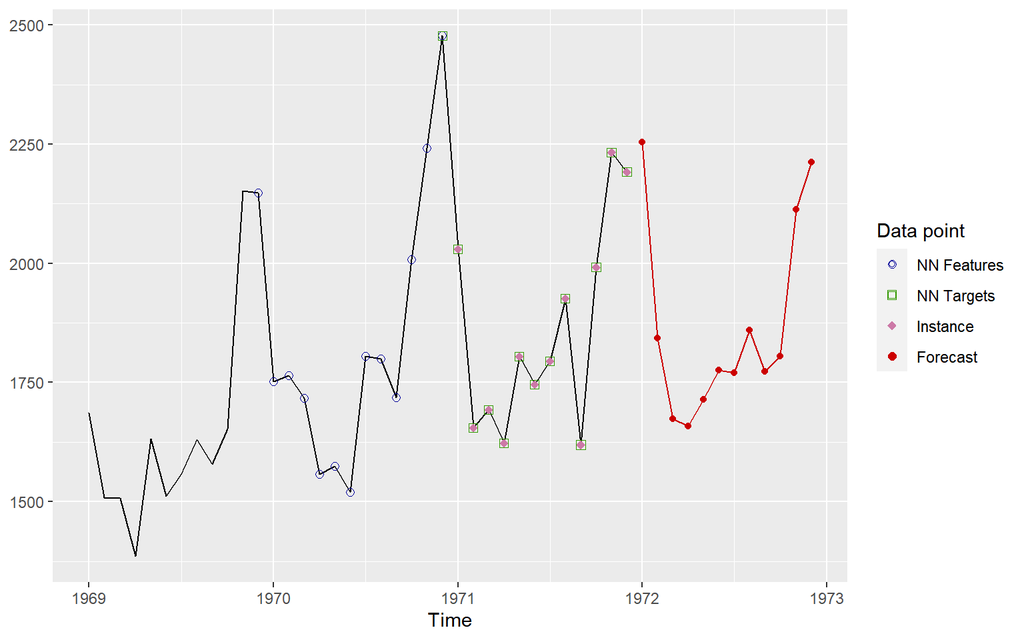

$~$$~$ Zaman serilerinin son 12 değeri, hedefi tahmin edilmesi gereken yeni örneğin(instance) özellikleridir. Bu örneğe en çok benzeyen 12 ardışık değerden oluşan iki dizi(seri) bulunur (mavi renkte) ve sonraki 12 değerin (yeşil) ortalaması alınır ve tahmini değer (kırmızı) elde edilir.

### 3.2.2 Özyinelemeli Strateji

$~$$~$ Özyinelemeli veya yinelemeli strateji, birkaç periyodu tahmin etmek için kullanılan yaklaşımdır. Bu stratejide sadece bir adım ileriyi tahmin eden bir model kullanılmaktadır. Bu nedenle, model tüm gelecek dönemleri tahmin etmek için yinelemeli olarak uygulanır. Yeni örneğin özellikleri olarak kullanılacak tarihsel gözlemler mevcut olmadığında, bunun yerine önceki tahminler kullanılır. $~$$~$ Özyinelemeli strateji bir adım ileri model kullandığı için, bunun anlamı, KNN durumunda, bir eğitim örneğinin hedefinin yalnızca bir değer içerdiği anlamına gelir. Örneğin, aylık bir zaman serisinin gelecek iki ayının tahmin edildiği aşağıdaki örnekle yinelemeli stratejinin nasıl çalıştığını inceleyelim:

```
       Jan   Feb   Mar   Apr   May   Jun   Jul   Aug   Sep   Oct   Nov   Dec
1973  9007  8106  8928  9137 10017 10826 11317 10744  9713  9938  9161  8927
1974  7750  6981  8038  8422  8714  9512 10120  9823  8743  9129  8710  8680
1975  8162  7306  8124  7870  9387  9556 10093  9620  8285  8466  8160  8034
1976  7717  7461  7767  7925  8623  8945 10078  9179  8037  8488  7874  8647
1977  7792  6957  7726  8106  8890  9299 10625  9302  8314  8850  8265  8796
1978  7836  6892  7791  8192  9115  9434 10484  9827  9110  9070  8633  9240
```

$~$$~$ **USAccDeaths** veri seti, 1973 ve 1978 yılları arasında ABD’deki kaza sonucu ölümlerin aylık toplamını veren bir zaman serisidir.

$~$$~$ knn_forecasting fonksiyonun **msas** argümanına **“recursive”** yazarak özyineleme stratejisini uygulayabiliriz.

```
       Jan   Feb   Mar   Apr   May   Jun   Jul   Aug   Sep   Oct   Nov   Dec
1973  9007  8106  8928  9137 10017 10826 11317 10744  9713  9938  9161  8927
1974  7750  6981  8038  8422  8714  9512 10120  9823  8743  9129  8710  8680
1975  8162  7306  8124  7870  9387  9556 10093  9620  8285  8466  8160  8034
```

```
      Lag12 Lag11 Lag10  Lag9  Lag8  Lag7  Lag6  Lag5  Lag4  Lag3  Lag2  Lag1
 [1,]  9007  8106  8928  9137 10017 10826 11317 10744  9713  9938  9161  8927
 [2,]  8106  8928  9137 10017 10826 11317 10744  9713  9938  9161  8927  7750
 [3,]  8928  9137 10017 10826 11317 10744  9713  9938  9161  8927  7750  6981
 [4,]  9137 10017 10826 11317 10744  9713  9938  9161  8927  7750  6981  8038
 [5,] 10017 10826 11317 10744  9713  9938  9161  8927  7750  6981  8038  8422
         H1
 [1,]  7750
 [2,]  6981
 [3,]  8038
 [4,]  8422
 [5,]  8714
 [ reached getOption("max.print") -- omitted 19 rows ]
```

$~$$~$ **Peki nasıl çalışır ?**

- İlk özellik vektörü zaman serisindeki ilk yılın 12 ayıdır.
- İlk hedef vektörü ise zaman serisindeki ikinci yılın ilk ayıdır.
- İkinci özellik vektörü, zaman serisindeki ilk yılın ilk ayından hemen sonraki 12 aydır.
- İkinci hedef vektörü ise zaman serisine göre ilk hedef vektöründen hemen sonraki ilk aydır.
- Üçüncü özellik vektörü, zaman serisindeki ilk yılın ikinci ayından hemen sonraki 12 aydır.
- Üçüncü hedef vektörü ise,zaman serisine göre ikinci hedef vektöründen hemen sonraki ilk aydır.
- …
- n özellik vektörü, zaman serisindeki son yılın son ayından hemen önceki 12 aydır.
- n hedef vektörü ise zaman serisindeki son yılın son ayıdır.

$~$$~$ nearest_neighbors fonksiyonu ile hedefi tahmin edilen yeni örneğe ve en yakın komşularıa bakalım:

```
[[1]]
[[1]]$instance
Lag 12 Lag 11 Lag 10  Lag 9  Lag 8  Lag 7  Lag 6  Lag 5  Lag 4  Lag 3  Lag 2
  8162   7306   8124   7870   9387   9556  10093   9620   8285   8466   8160
 Lag 1
  8034

[[1]]$nneighbors
  Lag 12 Lag 11 Lag 10 Lag 9 Lag 8 Lag 7 Lag 6 Lag 5 Lag 4 Lag 3 Lag 2 Lag 1
1   7750   6981   8038  8422  8714  9512 10120  9823  8743  9129  8710  8680
2   6981   8038   8422  8714  9512 10120  9823  8743  9129  8710  8680  8162
    H1
1 8162
2 7306


[[2]]
[[2]]$instance
Lag 12 Lag 11 Lag 10  Lag 9  Lag 8  Lag 7  Lag 6  Lag 5  Lag 4  Lag 3  Lag 2
  7306   8124   7870   9387   9556  10093   9620   8285   8466   8160   8034
 Lag 1
  7734

[[2]]$nneighbors
  Lag 12 Lag 11 Lag 10 Lag 9 Lag 8 Lag 7 Lag 6 Lag 5 Lag 4 Lag 3 Lag 2 Lag 1
1   6981   8038   8422  8714  9512 10120  9823  8743  9129  8710  8680  8162
2   8038   8422   8714  9512 10120  9823  8743  9129  8710  8680  8162  7306
    H1
1 7306
2 8124
```

- **nearest_neighbors** fonksiyonu bize tahmin etmeye çalıştığımız hedeflerin yeni örneklerini veya özellik vektörlerini ve bu özellik vektörüne en yakın olan 2 komşularının özelliklerinin ve hedeflerinin vektörünü verir.

$~$$~$ **En yakın iki komşu ise şu şekilde belirlenir:**

- İlk olarak 1976 yılının Ocak ayını tahmin etmek için bir özellik vektörü ve en yakın 2 komşusunun özellik vektörü ve hedef değerlerini verdikten sonra tahmin edilen değer 1976 yılının Şubat ayını tahmin etmek için hedef değeri olarak ele alınır. Bu durumda 2. tahmin için özellik vektörü 1976 yılının Ocak ayı dahil geriye dönük ilk 12 aydır. 1976 yılının Ocak ayı ise ilk tahmin için en yakın 2 komşunun hedef değerlerinin ortalaması alınmış değeriydi. 2. tahmin için gerekli olan en yakın 2 komşu ise tüm özellik vektörleri üzerinde tekrar öklid hesaplayarak bulunur. Bu hesaplamaya ilk tahmin etmeye çalıştığımız 1976 yılının Ocak ayına ait özellik vektörünü dahil etmez.
- **knn_examples(pred)** ile elde ettiğimiz gecikmeleri ve hedefleri bir matrise dönüştürerek en yakın 2 komşuyu kendimiz bulmak istersek:

```
 [1] 13 14 24 15 12 23 16  1 11 17  2 22 18  3 20 10 19 21  4  9  5  8  6  7
```

```
 [1] 14 15 16 13 24 17  2 12  3 18 23  1 19  4 11 22 21 20  5 10  6  9  7  8
```

$~$$~$ Kendimiz elde etmek istediğimizde de öklid mesafelerine bakarak ilk tahmin için en yakın 2 komşunun, knn_examples(pred) sonucundaki 13. ve 14. satır olduğunu ve 2. tahmin için en yakın 2 komşunun, knn_examples(pred) sonucundaki 14. ve 15. özellik vektörleri olduğunu bu kod ile de teyit etmiş olduk.

```
      Jan  Feb
1976 7734 7715
```

$~$$~$ 1976 yılının Ocak ayını 7734 ve Şubat ayını 7715 adet olarak bulmuştur.. Bu değer, tahmin etmeye çalıştığımız hedeflerin özellik vektörüne en yakın olan 2 komşusunun hedef değerlerinin ortalamasıdır.

[figure not shown]

## 3.3 KNN parametrelerini ayarlama

$~$$~$ Bir KNN modeli seçmek için aşağıdaki parametrelerin seçilmesi gerekir:

- En yakın komşuları bulmak için kullanılan mesafe fonksiyonu.
- En yakın komşuların hedeflerini toplamak için kullanılan kombinasyon fonksiyonu
- En yakın komşuların sayısı, yani k parametresi.
- Otoregresif açıklayıcı değişkenler olarak kullanılan gecikmeler, yani eğitim örneklerini tanımlayan özellikler.

## 3.4 Farklı k parametrelerine sahip birkaç modelden oluşan bir topluluk

$~$$~$ Bir KNN modelini belirlemek için k parametresinin seçilmesi gerekir. K çok küçükse, tahmin gürültüden daha kolay etkilenebilir. Öte yandan, k çok büyükse, yeni örnekten çok uzak örnekler kullanıyoruz. K parametresini seçmek için birkaç strateji kullanılabilir.

$~$$~$ İlk, hızlı, basit bir çözüm sezgisel kullanmaktır — k’yi eğitim örneklerinin sayısının kareköküne ayarlamanız önerilir. Diğer bir yaklaşım, bir doğrulama setinde bir optimizasyon aracı kullanarak k’yi seçmektir. k MAPE gibi bir tahmin doğruluğu ölçüsünü en aza indirmelidir (Hyndman ve Koehler, 2006).

$~$$~$ (Martínez ve diğerleri, 2017) ’de incelenen üçüncü bir strateji, farklı k değerlerine sahip birkaç KNN modelini kullanmaktır. Her KNN modeli kendi tahminlerini üretir ve farklı modellerin tahminlerinin ortalaması alınarak nihai tahmini oluşturulur. Bu strateji, zaman serisi tahmininde model kombinasyonunun başarısına dayanmaktadır (Hibon ve Evgeniou, 2005).

$~$$~$ Tsfknn paketi ile bu stratejiyi k değerlerinin bir vektörünü belirleyerek kullanabilirsiniz:

```
          Jan      Feb      Mar      Apr      May      Jun      Jul      Aug
1980 2865.375 2866.250 2728.875 2189.000 1816.000 1625.875 1526.250 1404.250
          Sep      Oct      Nov      Dec
1980 1354.000 1541.250 1699.250 2198.750
```

$~$$~$ Birden fazla k tanımlaması yaparak tahminleme yapmak **MIMO** stratejisi tabanlıdır. Önce k=2 için daha sonra k=4 için çalışır.Oluşan iki modelin tahmin($prediction) değerlerinin ortalamasını alır.

$~$$~$ Bu örnekte, k sırasıyla 2 ve 4’e eşit olan iki KNN modeli oluşturulmuştur. Tahmin, her iki model tarafından üretilen tahminlerin ortalamasıdır. Hedefler ağırlıklar kullanılarak birleştirilirse, k parametresinin seçiminin daha az önemli olduğu da not edilmelidir çünkü komşular yeni örnekten uzaklaştıkça kilo kaybederler. Ağırlıklı kombinasyon seçildiğinde, genelleştirilmiş gerileme sinir ağlarının yaptığı gibi k’yi eğitim örneklerinin sayısına ayarlamak bile mantıklıdır (Yan, 2012).

## 3.5 Varsayılan parametreler

$~$$~$ Bazen çok sayıda zaman serisinin tahmin edilmesi gerekir. Bu durumda, tahminleri oluşturmanın otomatik bir yolu çok kullanışlıdır. Bu anlamda, bu pakette mantıklı varsayılan parametreleri kullanabilir. Kullanıcı yalnızca zaman serisini ve tahmin ufkunu belirtirse, KNN parametreleri aşağıdaki gibi seçilir:

- Çok adımlı ileriye dönük strateji olarak MIMO seçilmiştir.
- Hedefleri toplamak için kullanılan kombinasyon işlevi ortalamadır.
- k sırasıyla 3, 5 ve 7 en yakın komşuyu kullanan üç modelin kombinasyonu olarak seçilir.

*Otoregresif gecikmeleri seçmek için aşağıdaki strateji kullanılır:

$~$$~$ Zaman serisi mevsimsel ise ve mevsimsel dönemin uzunluğu m ise, 1: m gecikmeler kullanılır. Örneğin, üç aylık veri gecikmeleri için 1: 4 ve aylık veri gecikmeleri için 1:12 seçilir. Bu şekilde mevsimsel desenler daha kolay yakalanabilir.

## 3.6 Tahmin doğruluğunu değerlendirme

$~$$~$ Bir model oluşturulduktan sonra, tahmin doğruluğunu değerlendirmek istenebilir. Tsfknn paketinde bu, rolling_origin fonksiyonu ile yapılır. Bu fonksiyon, bir veri kümesini eğitim ve test kümelerine ayırmanın klasik yaklaşımını kullanır.

$~$$~$ Zaman serisi tahmininde test seti, zaman serilerinin son gözlemlerinden oluşur. Örneğin:

```
      Jan  Feb  Mar  Apr  May  Jun  Jul  Aug  Sep  Oct  Nov  Dec
1974 3035 2552 2704 2554 2014 1655 1721 1524 1596 2074 2199 2512
1975 2933 2889 2938 2497 1870 1726 1607 1545 1396 1787 2076 2837
1976 2787 3891 3179 2011 1636 1580 1489 1300 1356 1653 2013 2823
1977 3102 2294 2385 2444 1748 1554 1498 1361 1346 1564 1640 2293
1978 2815 3137 2679 1969 1870 1633 1529 1366 1357 1570 1535 2491
1979 3084 2605 2573 2143 1693 1504 1461 1354 1333 1492 1781 1915
```

$~$$~$ **ldeaths** veri seti 1974-1979 arasında İngiltere’de bronşit, amfizem ve astımdan aylık ölümleri gösteren bir zaman serisidir.

```
$knnf

Call:  knn_forecasting(timeS = ldeaths, h = 12, lags = 1:12, k = 2)

Multiple-Step Ahead Strategy: MIMO
K (number of nearest neighbors): 2
Autoregressive lags: 1 2 3 4 5 6 7 8 9 10 11 12
Number of examples: 49
Targets are combined using the mean function.

$test_sets
      h=1  h=2  h=3  h=4  h=5  h=6
[1,] 1461 1354 1333 1492 1781 1915

$predictions
        h=1    h=2    h=3  h=4    h=5  h=6
[1,] 1513.5 1363.5 1351.5 1567 1587.5 2392

$errors
       h=1  h=2   h=3 h=4   h=5  h=6
[1,] -52.5 -9.5 -18.5 -75 193.5 -477

$global_accu
      RMSE        MAE       MAPE
213.613748 137.666667   7.747168

$h_accu
           h=1       h=2       h=3      h=4       h=5       h=6
RMSE 52.500000 9.5000000 18.500000 75.00000 193.50000 477.00000
MAE  52.500000 9.5000000 18.500000 75.00000 193.50000 477.00000
MAPE  3.593429 0.7016248  1.387847  5.02681  10.86468  24.90862

attr(,"class")
[1] "knnForecastRO"
```

$~$$~$ Yukarıda bahsedildiği gibi, knn_forecasting bir KNN modeli oluşturur ve model hakkında bilgi içeren bir “knnForecast” nesnesi döndürür. **Rolling_origin** fonksiyonu birinci parametresi olarak bir “knnForecast” nesnesi alır. Buradan KNN modelinin zaman serileri ve metaparametreleri hakkında bilgi elde edilir; örneğin, otoregresif gecikmeler, en yakın komşuların sayısı veya çok adımlı ileri strateji bilgileri yer alır. Rolling_origin’in ikinci parametresi, test setinin boyutudur. Örnekte, boyut 6’dır ve bu nedenle, zaman serilerinin son 6 gözlemi test seti olarak ve kalan gözlemler eğitim seti olarak kullanılacaktır. rolling_origin, değerlendirme hakkında bilgi içeren bir “knnForecastRO” nesnesi döndürür.

$~$$~$ Örneğin, test seti, tahminler ve hatalara başvurulabilir:

```
      h=1  h=2  h=3  h=4  h=5  h=6
[1,] 1461 1354 1333 1492 1781 1915
```

$~$$~$ Zaman serisi verisinin son 6 verisi yani 1979 yılının son 6 ayı test veri seti olarak ayarlanmıştır.

```
        h=1    h=2    h=3  h=4    h=5  h=6
[1,] 1513.5 1363.5 1351.5 1567 1587.5 2392
```

```
       h=1  h=2   h=3 h=4   h=5  h=6
[1,] -52.5 -9.5 -18.5 -75 193.5 -477
```

$~$$~$ Zaman serisi veri setindeki son 6 ay test veri seti olarak ayarlanmış ve yine son 6 ay için tahminler knn_forecasting fonksiyonu ile hesaplanır. Test ve tahmin değerleri arasındaki fark hatalar olarak listelenebilir.

$~$$~$ Tahminler hakkında birkaç tahmin doğruluğu ölçüsüne başvurmak da mümkündür.

### 3.6.1 Bazı doğruluk ölçüleri

#### 3.6.1.1 [MSE] Ortalama Kare Hata (Mean Squared Error):

$$MSE=\frac{1}{n}\sum_{j=1}^n e_j^2$$

- Basitçe, ortalama kare hata bir regresyon eğrisinin bir dizi noktaya ne kadar yakın olduğunu söyler. MSE, bir makine öğrenmesi modelinin, tahminleyicinin performansını ölçer, her zaman pozitif değerlidir ve MSE değeri sıfıra yakın olan tahminleyicilerin daha iyi bir performans gösterdiği söylenebilir.

#### 3.6.1.2 [RMSE] Kök Ortalama Kare Hata (Root Mean Square Error):

$$RMSE=\sqrt{\frac{\sum_{j=1}^{n} e_j^2}{n}}$$

$$RMSE=\sqrt{MSE}$$

- Bir makine öğrenmesi modelinin, tahminleyicinin tahmin ettiği değerler ile gerçek değerleri arasındaki uzaklığın bulunmasında sıklıkla kullanılan, hatanın büyüklğünü ölçen kuadratik bir metriktir. RMSE tahmin hatalarının standart sapmasıdır. Yani, hataların, regresyon hattının veri noktalarından ne kadar uzakta olduğunun bir ölçüsüdür; RMSE ise bu hataların ne kadar yayıldığının bir ölçüsüdür. Başka bir deyişle, verilere en iyi uyan çizgi etrafında o verilerin ne kadar yoğun olduğunu söyler. RMSE değeri 0’dan ∞’a kadar değişebilir. Daha düşük değerlere sahip tahminleyiciler daha iyi performans gösterir. RMSE değerinin sıfır olması modelin hiç hata yapmadığı anlamına gelir. RMSE, birçok matematiksel hesaplamada istenmeyen mutlak değerin kullanılmasını engeller.

#### 3.6.1.3 [MAPE] Ortalama Mutlak Yüzde Hata (Mean Absolute Percentage Error):

$$MAPE=\frac{100}{n}\sum_{j=1}^n \frac{|e_j|}{|A_j|}$$

- Regresyon ve zaman serileri modellerinde tahminlerin doğruluğunu ölçmek için ortalama mutlak yüzde hata sıkça kullanılmaktadır. Gerçek değerler arasında sıfır içerenler varsa, sıfır ile bölünme olacağı için MAPE hesaplanamaz. Çok düşük tahmin değerleri için yüzde hatası %100’ü geçemez, ancak çok yüksek tahmin değerleri olduğunda yüzde hatasının üst sınırı yoktur. MAPE, tahminleyicilerin doğruluğunu karşılaştırmak için kullanıldığında, tahminleri çok düşük olan bir yöntemi sistematik olarak seçmesi nedeniyle önyargılıdır. Bu ufak ama ciddi problemin, tahmin değerlerin gerçek değerlerine oranını bulan bir doğruluk ölçütü ile üstesinden gelinebilir. Bu yaklaşım geometrik ortalama açısından yorumlanabilen tahminlere yol açar.

#### 3.6.1.4 [MAE] Ortalama Mutlak Hata (Mean Absolute Error):

$$MAE=\frac{1}{n}\sum_{j=1}^n |e_j|$$

- Ortalama mutlak hata iki sürekli değişken arasındaki farkın ölçüsüdür. MAE, her gerçek değer ile veriye en iyi uyan çizgi arasındaki ortalama dikey mesafedir. MAE aynı zamanda her veri noktası ile en iyi uyan çizgi arasındaki ortalama yatay mesafedir. MAE değeri kolay yorumlanabilir olduğu için regresyon ve zaman serisi problemlerinde sıkça kullanılmaktadır. MAE, yönlerini dikkate almadan bir dizi tahmindeki hataların ortalama büyüklüğünü ölçen, tüm hataların ortalamada eşit olarak ağırlıklandırıldığı doğrusal bir skordur. MAE değeri 0’dan ∞’a kadar değişebilir. Daha düşük değerlere sahip tahminleyiciler daha iyi performans gösterir.

```
      RMSE        MAE       MAPE
213.613748 137.666667   7.747168
```

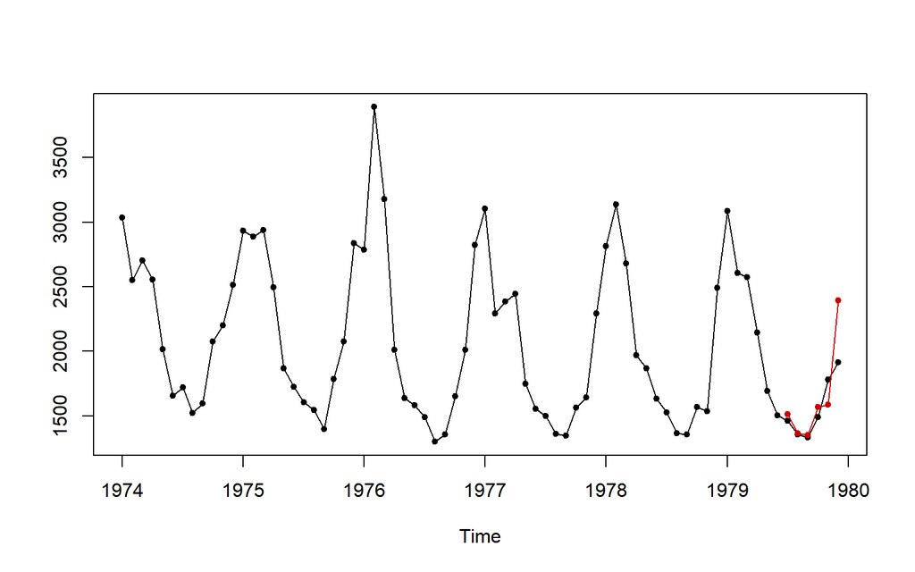

$~$$~$ Bu şekilde, zaman serilerinin son altı gözlemi test setidir ve tahminler kırmızı noktalardır.

## 3.7 Bir Rolling Origin’e dayalı değerlendirme

$~$$~$ Eğitim / test setlerinin daha sofistike bir versiyonu, dönen bir başlangıç değerlendirmesi kullanmaktır. Fikir aşağıdaki gibidir. Bir zaman serisinin son n gözlemi test verileri olarak kullanılır. Ardından n değerlendirme yapılır. İlk değerlendirmede son n gözlem, test seti ve öncekiler eğitim setidir. Eğitim seti ile bir model takılır, tahminler oluşturulur ve hatalar gözlemlenir. İkinci değerlendirmede, son “n - 1” gözlemler test seti olarak kullanılır ve test setinin zaman serisinin son değeri olduğu son değerlendirmeye kadar bu şekilde devam eder. Şekil 9, bir zaman serisinin son altı değerinin rolling başlangıç noktası değerlendirmesi için farklı eğitim ve test setlerini göstermektedir. Görüldüğü gibi,

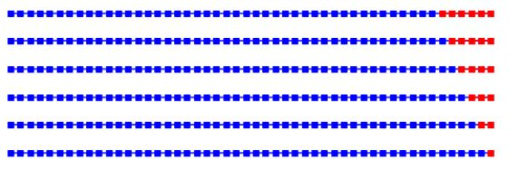

*6 gözlemle rolling başlangıç noktası değerlendirmesi için eğitim (mavi) ve test (kırmızı) setleri.*

$~$$~$ tahminlerin kaynağı zamanla ileri doğru döner. Döndürme kaynağı tekniği, değerlendirme açısından test verilerinden en iyi şekilde yararlanmayı amaçlamaktadır. Örneğin, test verilerinde n gözlemle, n bir adım önde tahmin, n - 1 iki adım ileride tahmin vb. Oluşturulur. Öte yandan, rolling başlangıç noktası değerlendirmesi zaman alan bir iştir çünkü birkaç modelin takılması gerekir.

$~$$~$ Rolling_origin fonksiyonu varsayılan olarak dönen kaynak değerlendirmesini kullanır:

```
      h=1  h=2  h=3  h=4  h=5  h=6
[1,] 1461 1354 1333 1492 1781 1915
[2,] 1354 1333 1492 1781 1915   NA
[3,] 1333 1492 1781 1915   NA   NA
[4,] 1492 1781 1915   NA   NA   NA
[5,] 1781 1915   NA   NA   NA   NA
[6,] 1915   NA   NA   NA   NA   NA
```

```
        h=1    h=2    h=3    h=4    h=5  h=6
[1,] 1513.5 1363.5 1351.5 1567.0 1587.5 2392
[2,] 1363.5 1351.5 1567.0 1587.5 2392.0   NA
[3,] 1351.5 1567.0 1587.5 2392.0     NA   NA
[4,] 1567.0 1587.5 2392.0     NA     NA   NA
[5,] 1587.5 2392.0     NA     NA     NA   NA
[6,] 2392.0     NA     NA     NA     NA   NA
```

```
        h=1    h=2    h=3    h=4    h=5  h=6
[1,]  -52.5   -9.5  -18.5  -75.0  193.5 -477
[2,]   -9.5  -18.5  -75.0  193.5 -477.0   NA
[3,]  -18.5  -75.0  193.5 -477.0     NA   NA
[4,]  -75.0  193.5 -477.0     NA     NA   NA
[5,]  193.5 -477.0     NA     NA     NA   NA
[6,] -477.0     NA     NA     NA     NA   NA
```

$~$$~$ Çıktıdaki her satır farklı bir değerlendirmeyi temsil eder. Şimdi, “knnForecastRO” nesnesinin global_accu alanı, tüm değerlendirmelerdeki tüm tahminlerin doğruluk ölçümlerini depolar:

```
     RMSE       MAE      MAPE
274.19569 202.69048  11.09727
```

$~$$~$ Farklı tahmin ufukları için tahmin doğruluğu ölçülerine de başvurulabilir:

```
            h=1        h=2       h=3       h=4       h=5       h=6
RMSE 213.613748 232.821283 260.25877 300.33107 363.98575 477.00000
MAE  137.666667 154.700000 191.00000 248.50000 335.25000 477.00000
MAPE   7.747168   8.577916  10.54699  13.60004  17.88665  24.90862
```

$~$$~$ Beklendiği gibi, hatalar artan ufukla birlikte büyüyor.

$~$$~$ Son olarak, yuvarlanan kaynak değerlendirmesi ile gerçekleştirilen farklı tahminlerin herhangi birinin grafiği elde edilebilir. Örneğin:

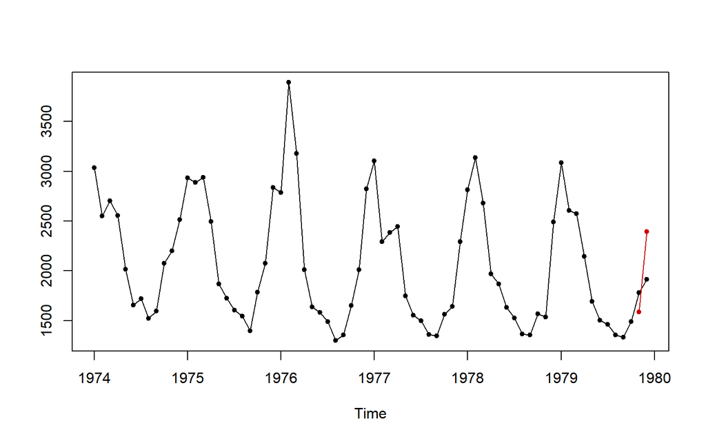

$~$$~$ Bu şekilde, son iki gözlemle test seti için tahmin gösterilmiştir.

## 3.8 Diğer Zaman Serisi Tahmin Paketleriyle Karşılaştırma

$~$$~$ Bu bölümde paketimiz, R’da tek değişkenli zaman serisi tahmini için kullanılan diğer yazılımlarla karşılaştırılmıştır.

$~$$~$ CRAN Task Views’da ,zaman serisi tahminlerine yönelik bazı modeller bulunabilir. CRAN görev görünümleri, CRAN’daki hangi paketlerin belirli bir konuyla ilgili görevler için uygun olduğuna dair bazı rehberlik sağlamayı amaçlamaktadır. Time Series, Econometrics ve Finance bölümünde zaman serisi tahmini için bazı modeller bulunur.

$~$$~$ Bu paketlerde bulunan fonksiyonların çoğu, ARIMA veya üstel düzleştirme gibi istatistiksel modeller kullanır. **“Forecast”** paketi, zaman serisi tahmini için tartışmasız en iyi pakettir. *Stats* paketinde bulunabilen tüm modelleri ve Theta yöntemi veya çok katmanlı algılayıcı gibi diğer birçok modeli uygular. Ayrıca bu paket, mevsimsel zaman serilerini çizmek, Box-Cox dönüşümlerini yapmak vb. İçin ek araçlar içerir. Bu paket ile en yakından ilgili paketler, makine öğrenimi yaklaşımlarına dayalı olanlardır.

**Aşağıda, bu paketlerin kısa bir açıklaması verilmiştir:**

**GMDH**

$~$$~$ Bu pakette, tek değişkenli bir zaman serisi için kısa vadeli tahmin yapmak için GMDH tipi sinir ağı algoritmaları uygulanmaktadır (Dag ve Yozgatligil, 2016). Veri işleme grup yöntemi (GMDH) türünde sinir ağı algoritmaları, karmaşık sistemleri modellemeye yarayan bulgusal, kendi kendini organize eden yöntemlerdir.

- Grup veri işleme yöntemi (GMDH) - türü sinir ağı algoritması, karmaşık sistemleri modellemek için sezgisel kendi kendine organize etme yöntemidir. Bu pakette, tek değişkenli bir zaman serisi için kısa vadeli tahmin yapmak için GMDH tipi sinir ağı algoritmaları uygulanır. GMDH türünde sinir ağı algoritmalarına, zaman serisi veri setleri için öngörü yapmak amacıyla başvurulmuştur. Karşılaştırma amaçlı ARIMA modelleri ve üstel düzgünleştirme yöntemleri de dahil edildi. GMDH algoritmalarının diğer yöntemlerle aynı hatta daha iyi performans gösterdiği saptanmıştır.

**NTS**

$~$$~$ Bu paket, kullanıcıların bir sinir ağını beslemek için gereken örnekleri oluşturmasına olanak tanıyan **NNsetting** fonksiyonunu içerir. Ancak paket, tahminlerin doğrudan oluşturulmasına izin vermez.

- Doğrusal olmayan zaman serisi analizi için simülasyon, tahmin, tahmin prosedürü ve model tanımlama yöntemleridir.

**tsDyn**

$~$$~$ Kullanıcıların, **nnet** paketinden **nnet** fonksiyonu kullanılarak hesaplanan tek bir gizli katman ile çok katmanlı bir algılayıcı kullanarak bir zaman serisini tahmin etmelerini sağlar.

- Doğrusal olmayan otoregresif (AR) zaman serisi modellerinde uygulanır.
- Tek katmanlı yapay sinir ağları sadece girdi ve çıktı (Ç) katmanlarından oluşur. Çok katmanlı yapay sinir ağları, ara katmanlar girdi katmanından gelen bilgileri işleyerek bir sonraki katmana gönderir.

**nnfor**

$~$$~$ Çok katmanlı algılayıcılar oluşturmak için **neuralnet** paketini kullanılır. **elm** fonksiyonu aracılığıyla aşırı öğrenme makinelerini kullanmak da mümkündür.

- Aşırı öğrenme makineleri, tek gizli katmana sahip ileri beslemeli yapay sinir ağlarını eğitmek için önerilen bir yöntemdir.

**forecast**

$~$$~$ Bu paket, gizli bir katmana sahip çok katmanlı bir algılayıcı kullanarak bir zaman serisini tahmin etmek için kullanılan **nnetar** fonksiyonunu kullanır.

$~$$~$ Aşağıdaki özellikler açısından bu paketlerin bir karşılaştırmasını tablo şeklinde görebiliriz:

- Keyfi otoregresif gecikmeler kullanmak mümkün müdür? Örneğin bazı paketlerde gecikmeler ardışık değerler olmalıdır.
- Yalnızca zaman serilerini ve tahmin ufkunu gösteren tahminleri oluşturmak mümkün müdür?
- Tahminleri ve diğer bilgileri plot ile çizmek için paket araçları içeriyor mu?
- Rolling origin (Dönen kaynak) değerlendirmesi uygulanıyor mu?
- Paket tahminler için tahmin aralıkları oluşturuyor mu?
- Modelde tahminleyiciler olarak dışsal değişkenleri dahil etmek mümkün müdür?

| Paketler | GMDH | tsDyn | nnfor | forecast | tsfknn |
| --- | --- | --- | --- | --- | --- |
| Keyfi Gecikmeler | Hayır | Hayır | Evet | Hayır | Evet |
| Varsayılan Parametreler | Evet | Hayır | Evet | Evet | Evet |
| Plot Çizimi | Hayır | Evet | Evet | Evet | Evet |
| Rolling Orijin Değerlendirmesi | Hayır | Hayır | Evet | Evet | Evet |
| Tahmin Aralıkları | Evet | Hayır | Hayır | Evet | Hayır |
| Dışsal Değişkenler | Hayır | Hayır | Evet | Evet | Hayır |

Tablo 2: Makine öğrenimi yaklaşımlarını kullanan paketlerin özellikleri.

**Rolling Origin:**

$~$$~$ Veriler için en uygun tahmin modelini veya yöntemini seçmeye ihtiyaç duyulduğunda, tahminciler genellikle mevcut numuneyi iki bölüme ayırır: in-sample (“eğitim seti”) ve holdout sample (veya out-sample veya " Deneme seti“). Model daha sonra örneklem içinde tahmin edilir ve tahmin performansı uzatma örnekleminde bazı hata ölçümleri kullanılarak değerlendirilir. Böyle bir prosedür yalnızca bir kez yapılırsa, buna “sabit kaynak” değerlendirmesi denir. Ancak, zaman serileri aykırı değerler veya seviye kaymaları içerebilir ve zayıf bir model, yalnızca bu nedenle daha uygun olandan daha iyi performans gösterebilir. Modellerin değerlendirilmesini sağlamlaştırmak için “yuvarlanma orijini” denen bir şey kullanılır. Dönen orijin, tahmin kaynağının art arda güncellendiği ve tahminlerin her kaynaktan üretildiği bir değerlendirme tekniğidir (Taşman 2000). Bu teknik, zaman serileri için çeşitli tahmin hatalarının elde edilmesini sağlar ve bu da modellerin nasıl performans gösterdiğinin daha iyi anlaşılmasını sağlar.

$~$$~$ Tahmin doğruluğuna ve çalışma süresine göre bu paketlerde bulunan yöntemlerin bir karşılaştırmasını da yaptık. Bu amaçla, NN3 tahmin yarışmasından (Crone vd., 2011) elde edilen veriler kullanılmıştır. Bu yarışmada 111 aylık zaman serisi sektör verileri kullanıldı. Serinin uzunluğu 52 ila 120 gözlem arasında değişiyor ve ayrıca mevsimsel ve mevsimsel olmayan serilerin dengeli bir karışımı vardır. NN3 yarışmasında olduğu gibi, her zaman serisinin gelecek 18 ayı tahmin edilmelidir. MAPE, tahmin doğruluğunu değerlendirmek için kullanılmıştır. Gerçek değerleri X olan bir NN3 zaman serisi için F tahmini verildiğinde:

$$MAPE= \frac{100}{18}\sum_{t=1}^{18} |\frac{X_t-F_t}{X_t}|$$

$~$$~$ Belirli bir yöntem verildiğinde, MAPE’si 111 zaman serisi için hesaplanır ve global bir MAPE elde etmek için ortalaması alınır. Bu global MAPE, farklı yöntemler için Tablo 3’ün ilk satırında görülmektedir. Karşılaştırmada GMDH paketi dahil edilmemiştir çünkü kullanıcıların en fazla 5 adım ileriyi tahmin etmesine izin verir. elm ve mlp, sırayla aşırı öğrenme makinelerini ve çok katmanlı algılayıcıları hesaplamak için nnfor paketinin fonksiyonlarıdır. auto.arima ve ets, ARIMA ve üstel yumuşatma uygulayan “forecast” paketine ait fonksiyonlardır. Fonksiyonları çağırırken mümkün olduğunca az parametre belirledik, böylece fonksiyonlar otomatik olarak veya varsayılan olarak parametrelerin değerini seçer. İstatistiksel modeller arasında en iyi sonuçları elde etti. Makine öğrenimi yaklaşımları arasında kazanan paketimizdir.

$~$$~$ Tablo 3’ün ikinci satırında, modelin fitlenmesi ve tahminlerin oluşturulması için gereken saniye cinsinden süre gösterilmektedir. Paketimiz en hızlı yöntemlerden biri olduğu için yöntemler arasında önemli farklılıklar bulunmaktadır.

| PackageOrFunction | tsDyn | elm | mlp | nnetar | auto.arima | ets | tsfknn |
| --- | --- | --- | --- | --- | --- | --- | --- |
| MAPE | 20.73 | 18.76 | 20.95 | 18.38 | 15.64 | 15.52 | 17.06 |
| Time | 2 | 3332 | 690 | 15 | 421 | 105 | 4 |

**Tsfknn paketindeki fonksiyonlar ve yöntemler**

$~$$~$ Makalede daha önce açıklanmayan fonksiyonların nasıl kullanılacağına dair bir örnek verilmiştir. Yöntemler yazdırılır ve özetlenir, beklenen sonucu üretir, yani model ve tahmini hakkında bazı bilgiler gösterirler:

```
Call:  knn_forecasting(timeS = mdeaths, h = 3)

Multiple-Step Ahead Strategy: MIMO
K (number of nearest neighbors): 3 models with 3, 5 and 7 neighbors respectively
Autoregressive lags: 1 2 3 4 5 6 7 8 9 10 11 12
Number of examples: 58
Targets are combined using the mean function.
```

```
Call:  knn_forecasting(timeS = mdeaths, h = 3)

Multiple-Step Ahead Strategy: MIMO
K (number of nearest neighbors): 3 models with 3, 5 and 7 neighbors respectively
Autoregressive lags: 1 2 3 4 5 6 7 8 9 10 11 12
Number of examples: 58
Targets are combined using the mean function.
Forecasting horizon: 3
Forecast:
          Jan      Feb      Mar
1980 1990.562 2106.390 1999.143
```

$~$$~$ Yöntem tahmini, önceden fitted edilmiş bir modeli kullanarak yeni tahminler oluşturmak için kullanılır:

```
        Jan    Feb    Mar    Apr    May    Jun    Jul    Aug    Sep    Oct
1980 2141.0 2052.0 1894.0 1477.0 1570.5 1216.5 1130.0 1045.5  991.5 1049.5
        Nov    Dec
1980 1144.5 1520.5
```

$~$$~$ Son olarak, **n_training_examples**, kaç eğitim örneğinin bir modele sahip olacağını bilmek için kullanışlı bir işlevdir:

```
[1] 58
```

# 4 Sonuç

$~$$~$ Zaman serisi tahminine hesaplamalı zeka regresyon yöntemlerini uygulamak için R’de neredeyse hiç paket yoktur. Bu yazıda, kullanıcıların KNN regresyonunu kullanarak bir zaman serisini tahmin etmelerini sağlayan tsfknn paketini sunduk. Paketin arayüzü oldukça basittir ve kullanıcıların bir KNN modeli belirlemesine ve modeli kullanarak bir zaman serisini tahmin etmesine olanak tanır. Ayrıca, tahminin nasıl hesaplandığını gösteren birkaç grafik oluşturulabilir.

# 5 Kaynakça

- Zhu, Hao, “Create Awesome HTML Table with knitr::kable and kableExtra” 2020,

  https://cran.r-project.org/web/packages/kableExtra/vignettes/awesome_table_in_html.html#Table_Footnote.
- Demir, Harun, “R Üzerinde Zaman Serisi Analizi Bölüm 1: Zaman Serisi Regresyonu” 2018,

  https://ravenfo.com/2018/12/24/r-uzerinde-zaman-serisi-analizi-bolum-1-zaman-serisi-regresyonu/
- Ova, Murat, “Zaman Serisi Nedir? R ile Zaman Serisi Analizine Giriş” 2019,

  https://productphilosophy.com/zaman-serisi-analizi/
- Uzun, Erdinç, “04.01. K-NN Algoritması” 2021,

  https://erdincuzun.com/makine_ogrenmesi/k-nn-algoritmasi/
- Ulgen, E.Kaan, “Makine Öğrenimi Bölüm-2 (k-En Yakın Komşuluk)” 2017,

  https://medium.com/@k.ulgen90/makine-%C3%B6%C4%9Frenimi-b%C3%B6l%C3%BCm-2-6d6d120a18e1
- Şana, Musa, “KNN ALGORITMASI VE ÖRNEK UYGULAMA” 2017,

  https://www.pythondersleri.com/2017/08/knn-algoritmas-ve-ornek-uygulama.html
- Özdemir, Koray, “K-En Yakın Komşu Algoritması (K-Nearest Neighbors Algorithm)” 2019,

  https://medium.com/batech/k-en-yak%C4%B1n-kom%C5%9Fu-algoritmas%C4%B1-k-nearest-neighbors-algorithm-16e5ab69af2e
- Marrs, Tyler, “Introduction to Matrix Profiles” 2019,

  https://towardsdatascience.com/introduction-to-matrix-profiles-5568f3375d90
- Disci, Selçuk, “Time Series Forecasting: KNN vs. ARIMA” 2020,

  https://www.r-bloggers.com/2020/09/time-series-forecasting-knn-vs-arima/
- Teknomo, Kardi, “KNN for Smoothing and Prediction” 2017,

  https://people.revoledu.com/kardi/tutorial/KNN/KNN_TimeSeries.htm
- Batur, Necati, “R ile Zaman Serisi Tahminleme” 2016,

  https://baturnecati.wordpress.com/2016/10/12/r-ile-zaman-serisi-tahminleme/comment-page-1/
- Martinez, Francisco, “Time Series Forecasting with KNN in R: the tsfknn Package” 2020,

  https://cran.r-project.org/web/packages/tsfknn/vignettes/tsfknn.html
- Akçay, Ayça, “K En Yakın Komşu (K Nearest Neighbour ) Algoritması — Sınıflama” 2020,

  https://aycaakcay.medium.com/k-en-yak%C4%B1n-kom%C5%9Fu-k-nearest-neighbour-algoritmas%C4%B1-s%C4%B1n%C4%B1flama-7c456f8e2b0d
- Arslan, Evren, “Makine Öğrenmesi — KNN (K-Nearest Neighbors) Algoritması Nedir?” 2020,

  https://medium.com/@arslanev/makine-%C3%B6%C4%9Frenmesi-knn-k-nearest-neighbors-algoritmas%C4%B1-bdfb688d7c5f
- Ergin, Tuncer, “K En Yakın Komşu (K-NN)” 2018,

  https://medium.com/@tuncerergin/k-en-yakin-komsu-53c93b3f8bd7
- Willems, Karlijn, “Machine Learning in R for beginners” 2018,

  https://www.datacamp.com/community/tutorials/machine-learning-in-r